# From Scores to Trust : A Statistical Quality Assessment for Diving Judges

Quantifying Rater Effects, Bias, and Reliability using Summary Data

Rongrong Qian (qianr5@miamioh.edu)

Jing Jing (jingj4@miamioh.edu)

Charntel Kazingizi (kazingcr@miamioh.edu)

Sagar Pangeni (pangens@miamioh.edu)

Advisor: Michael Hughes (hughesmr@miamioh.edu)

December 05, 2025

# 1 Introduction

Subjective scoring is a critical component in determining outcomes for elite sports, including diving. The inherent subjectivity of this process, however, introduces potential sources of measurement error, which can compromise the validity and fairness of competition results. In the context of statistical measurement theory, judges are viewed as “instruments,” and the quality of their scoring (the “measurement”) is paramount.

This report provides a quantitative analysis of judge scoring data to evaluate rater performance and identify specific measurement artifacts. The validity of competition rankings is contingent upon the reliability and impartiality of these ratings. Rater induced errors can manifest as poor reliability (e.g., intra-judge inconsistency over events) and systematic bias (e.g., rater severity/leniency, central tendency, or non-random favoritism).

The primary objective of this study is to summarize judge scoring behavior across multiple dimensions and convert these metrics into an overall performance rank using a penalty based scoring framework. Key aspects of the analysis include:

1. Reliability and consistency, assessing how stable each judge’s scores are relative to the panel baseline.
2. Bias and agreement, evaluating whether judges are systematically high or low and how closely their ranking of dives matches the panel consensus.
3. Extremeness and scale use, quantifying how often judges give extreme scores and how they use the available scoring range, with larger departures receiving higher penalties and contributing more to the overall rank.

This analysis aims to provide objective, data driven metrics for judge assessment, supporting efforts to ensure scoring integrity and guide future rater calibration.

# 2 Methods

## 2.1 Data

### 2.1.1 Data Description

The dataset is a consolidated collection of scoring records from multiple diving competitions, spanning the 2024 and 2025 seasons.

The data captures the scores awarded by a panel of judges for each individual dive. Per competition rules, these scores are issued on a standard 0-to-10 scale, typically in 0.5-point increments.

*A detailed description of all variables used in this analysis is provided in Appendix A.*

### 2.1.2 Data cleaning

#### 2.1.2.1 Merging 2024 and 2025 Data

To construct the analytic dataset, data from the 2024 and 2025 competition seasons were combined. This aggregation was performed to increase the overall sample size ($N$), thereby enhancing the statistical power and generalizability of the findings.

#### 2.1.2.2 Data Deduplication and Consistency Check

To maintain data integrity, a two-stage cleaning process is implemented to isolate unique scoring events:

1. Removal of exact duplicates: Exact duplicate rows are removed to avoid biasing variability measures and agreement metrics. There are 6304 exact duplicate rows removed in this step, leaving 67837 unique rows.
2. Verification of judge–dive uniqueness: A secondary check ensures that unique judge–dive combinations (stratified by year, meet, event, and judge) do not appear more than once in the final dataset. After deduplication, no judge–dive combination appears more than once, confirming data consistency.

#### 2.1.2.3 Flag anonymous judges

An indicator variable, `is_anonymous_judge`, is constructed to denote observations where the judge_id is missing. This flag facilitates the handling of unidentifiable judges, allowing for their exclusion from judge-specific modeling (e.g., random effects) or for separate descriptive summarization.

## 2.2 Statistical Assumptions

The analysis relies on the following assumptions regarding the data and scoring process:

1. **Judge Identifiability**: Individual assessment is restricted to judges with valid IDs. Anonymous data contribute to baseline calculations but are not assessed individually.
2. **Scoring Protocols**: Dive scores are computed using official rules based on panel size (2, 3, 5, or 7 judges).
3. **Independence**:Judges are assumed to score independently, with no collusion or dependence structure within panels.
4. **Metadata Integrity**: Dive attributes (e.g., difficulty, gender, team) are assumed to be accurate and free of systematic error.
5. **Consensus Validity & Panel Sufficiency**: The LOO panel aggregate serves as the proxy for “true” performance quality. This assumption is conditional on panel size ($N \ge 3$). Panels with fewer than 3 judges lack sufficient degrees of freedom to distinguish individual bias from consensus and are deemed unreliable for baseline comparison.

## 2.3 Statistical Analysis

This analysis is designed to provide a comprehensive, quantitative evaluation of individual judge performance in diving competitions. The objective is to quantify performance across five critical dimensions by referencing each judge against the collective judgment of their peers.

### 2.3.1 Leave one Judge out (LOO) Baseline

**1. Objective: Creating an Independent Standard**

To objectively assess the performance of any single judge, their scoring must be compared against a reliable, independent benchmark. This benchmark is established using the Leave-One-Out (LOO) method, which calculates the consensus score derived exclusively from all other judges in the panel. This effectively simulates the panel’s judgment if the target judge had not participated.

**2. Rationale: Ensuring a Robust Consensus**

The baseline must represent the true, shared agreement on a dive’s quality, not merely a simple average susceptible to error. A simple arithmetic mean is easily distorted by a single score that may represent a mistake, a mis-click, or an extreme outlier.

To mitigate this, the consensus is defined as a robust estimate of the panel’s view. When sufficient data is available, a Trimmed Mean is employed. This method excludes the most extreme high and low scores from the remaining panel before calculating the average, preventing outliers from skewing the final benchmark.

**3. Methodology and Data Integrity**

For each judge-dive pair $(j,d)$, the LOO Baseline ($BL_{d(-j)}$) is computed as follows:

$$BL_{d(-j)} =
\begin{cases}
\text{TrimmedMean}(y_{kd}) & \text{if } n_{-j} \ge 3 \\
\text{Mean}(y_{kd}) & \text{if } n_{-j} = 2 \\
\text{Flagged / NA} & \text{if } n_{-j} < 2
\end{cases}$$

Where:

- $BL_{d(-j)}$: LOO Baseline for dive $d$ excluding judge $j$.
- $y_{kd}$: Score given by judge $k$ for dive $d$.
- $n_{-j}$: The number of judges remaining in the panel after excluding judge $j$.

**Data Quality Constraint (Handling Insufficient Panels):**

Reliable consensus estimation requires a minimum number of reference points. Cases where the remaining panel size is small ($n_{-j} < 2$, corresponding to original panels of 2 judges) are flagged and excluded from consensus-based analysis.

Specifically, in a 2-judge panel, the LOO baseline for Judge A becomes solely Judge B’s score. In this scenario, any observed deviation represents a simple difference rather than a deviation from a true consensus. It becomes statistically impossible to distinguish Judge A’s bias from Judge B’s bias (it is an issue of identifiability). Consequently, such records are unreliable for baseline comparison and are treated as missing values.

### 2.3.2 Per-Dive Residuals

For each judge-dive pair $(j,d)$, several metrics need to be calculated to capture the judge’s deviation from the panel baseline.

**1. Residual ($r_{jd}$):**

The raw deviation of an individual judge’s score from the panel baseline for a single dive.

$$r_{jd} = y_{jd} - BL_{d(-j)}$$

Where:

- $r_{jd}$: Residual for judge $j$ on dive $d$.
- $y_{jd}$: Score given by judge $j$ for dive $d$.
- $BL_{d(-j)}$: LOO Baseline for dive $d$ excluding judge $j$.

**Interpretation:**

- A positive $r_{jd}$ indicates that judge $j$ scored dive $d$ higher than the panel baseline.
- A negative $r_{jd}$ indicates that judge $j$ scored dive $d$ lower than the panel baseline.

**2. Panel Volatility ($SD_{d(-j)}$):**

The standard deviation of the *other* judges. This measures how “controversial” the dive was.
$$SD_{d(-j)} = \text{sd}(y_{kd \in P_{d(-j)}})$$

Where:

- $SD_{d(-j)}$: Standard deviation of scores for dive $d$ excluding judge $j$.
- $y_{kd}$: Score given by judge $k$ for dive $d$.
- $P_{d(-j)}$: Set of all judges who scored dive $d$, excluding judge $j$.

**Interpretation:**

If $SD_{d(-j)}$ is very small, which means the dive was universally agreed upon, then even a small residual $r_{jd}$ indicates a significant deviation.

**3. Extremal Identity ($is\_max_{jd}$, $is\_min_{jd}$):**

A binary indicator (1/0) if $y_{jd}$ was the single highest or lowest score given for dive $d$.

- $is\_max_{jd} = 1$ if $y_{jd}$ is the unique maximum score for dive $d$.
- $is\_min_{jd} = 1$ if $y_{jd}$ is the unique minimum score for dive $d$.

**4. Edge Gap ($gap\_next_{jd}$):**

The absolute score difference between $y_{jd}$ and the next closest panel score. This metric is non-zero only if the judge is a unique extreme (i.e., $is\_max_{jd}=1$ or $is\_min_{jd}=1$). It measures how isolated the judge’s extreme score is from the next closest score in the same panel.

$$gap\_next_{jd} =
\begin{cases}
y_{jd} - \max(y_{kd \in P_{d(-j)}}) & \text{if } is\_max_{jd} = 1
\text{ (Unique Max)} \\
\min(y_{kd \in P_{d(-j)}}) - y_{jd} & \text{if } is\_min_{jd} = 1
\text{ (Unique Min)} \\
0 & \text{otherwise}
\end{cases}$$

Where:

- $gap\_next_{jd}$: Edge gap for judge $j$ on dive $d$.
- $y_{jd}$: Score given by judge $j$ for dive $d$.
- $P_{d(-j)}$: Set of all judges who scored dive $d$, excluding judge $j$.
- $\max(y_{kd \in P_{d(-j)}})$: The highest score given by the other judges (the closest score to a unique max).
- $\min(y_{kd \in P_{d(-j)}})$: The lowest score given by the other judges (the closest score to a unique min).

This flag identifies scores that are absolutely isolated from the rest of the panel, regardless of panel volatility.

**Interpretation:**

A large $gap\_next_{jd}$ indicates that judge $j$’s extreme score is far from the next closest score, suggesting a significant outlier.

### 2.3.3 Judge-Level Metric Aggregation

In this phase, the per-dive metrics across all dives $D_j$ (the set of all dives evaluated by judge $j$) need to be aggregated to create a comprehensive performance profile.

#### 2.3.3.1 Severity / Leniency

Measures the judge’s systematic bias.

$$SEV_j = \text{mean}(r_{jd} \mid d \in D_j)$$

Where:

- $SEV_j$: Severity/Leniency of judge $j$.
- $r_{jd}$: Residual for judge $j$ on dive $d$.
- $D_j$: Set of all dives evaluated by judge $j$.

**Interpretation:**

- A positive value indicates leniency (scores usually higher than panel baseline).
- A negative value indicates severity (scores usually lower).

#### 2.3.3.2 Inconsistency

Measures the judge’s volatility or “randomness.”

$$INC_j = \text{sd}(r_{jd} \mid d \in D_j)$$

Where:

- $INC_j$: Inconsistency of judge $j$.
- $r_{jd}$: Residual for judge $j$ on dive $d$.
- $D_j$: Set of all dives evaluated by judge $j$.

**Interpretation:**

- A low $INC_j$ means the judge is predictable (even if systematically severe/lenient).
- A high $INC_j$ indicates the judge is erratic and “noisy.”

#### 2.3.3.3 Range Utilization

Measures the judge’s tendency to use the full scale.

$$SPREAD_j = \text{sd}(y_{jd} \mid d \in D_j)$$

Where:

- $SPREAD_j$: Range Utilization of judge $j$.
- $y_{jd}$: Score given by judge $j$ for dive $d$.
- $D_j$: Set of all dives evaluated by judge $j$.

**Interpretation:**

- A low value indicates a “safe” judge who avoids high or low scores and clusters around the center.
- A high value indicates a judge willing to use the full range of scores.

#### 2.3.3.4 Range Ratio

However, a raw $SPREAD_j$ value is hard to interpret in isolation. To address this, the judge’s spread against the panel’s average spread is calculated:

$$RR_j = \frac{SPREAD_j}{\text{mean}(SD_{d(-j)} \mid d \in D_j)}$$

Where:

- $RR_j$: Range Ratio of judge $j$.
- $SPREAD_j$: Range Utilization of judge $j$.
- $SD_{d(-j)}$: Standard deviation of scores for dive $d$ excluding judge $j$.
- $D_j$: Set of all dives evaluated by judge $j$.

**Interpretation:**

- A value close to 1 indicates the judge’s spread matches the panel average.
- A value less than 1 indicates the judge uses a narrower range than the panel average.
- A value greater than 1 indicates the judge uses a wider range than the panel average.

#### 2.3.3.5 Agreement with Panel

Measures whether the judge’s *rank-ordering* of dives aligns with the panel’s. A judge can have high severity (e.g., $SEV_j = -0.5$) but still have high agreement ($CORR_j \approx 1$), meaning they correctly identify good vs. bad dives but just score them all 0.5 points lower.

$$CORR_{spearman, j} = \text{Cor}\left( \text{rank}(y_{jd}),
\text{rank}(BL_{d(-j)}) \mid d \in D_j \right)$$
*(Spearman correlation)*

Where:

- $CORR_j$: Agreement of judge $j$ with panel consensus.
- $rank(y_{jd})$: Rank of judge $j$’s score for dive $d$.
- $rank(BL_{d(-j)})$: Rank of the LOO Baseline for dive $d$.
- $D_j$: Set of all dives evaluated by judge $j$.

**Interpretation:**

- High positive value (close to +1): Indicates strong agreement. The judges rank the dives in the same order.
- Value close to 0: Indicates no relationship (randomness). The judges’ rankings are unrelated.
- High negative value (close to -1): Indicates strong disagreement (inverse relationship). The judges rank the dives in the opposite order (one loves it, one hates it).

#### 2.3.3.6 Extremeness

These metrics quantify how often and how far a judge is an outlier compared to the rest of the panel.

**Extremal Rate ($ER_j$):** The frequency (rate) at which the judge is the unique highest or lowest scorer on the panel.
$$\begin{aligned}
ER_j^{max} &= \text{mean}(\mathbf{1}(is\_max_{jd}) \mid d \in D_j)
\\
ER_j^{min} &= \text{mean}(\mathbf{1}(is\_min_{jd}) \mid d \in D_j)
\end{aligned}$$

Where:

- $ER_j^{max}$ (Lenience Rate): Proportion of dives where judge $j$ was the unique highest scorer.
- $ER_j^{min}$ (Severity Rate): Proportion of dives where judge $j$ was the unique lowest scorer.
- $is\_max_{jd}$, $is\_min_{jd}$: Indicators if judge $j$ was the unique max or min scorer on dive $d$.
- $D_j$: Set of all dives evaluated by judge $j$.

**Interpretation:**

Max Rate: This measures how often the judge gives the unique highest score.

Min Rate: This measures how often the judge gives the unique lowest score.

A judge can have high $ER_j$ which means this judge often gives the highest or lowest score, but if this judge always gives scores close to the next closest judge, the $z_{jd}$ will be small. Thus, the extremeness is only telling if the judge is frequently an outlier, but not *how much* of an outlier they are. So, another metric $EGI_j$ is needed to capture the *magnitude* of extremeness.

**Extreme Gap Index ($EGI_j$):** The average *magnitude* of the judge’s deviation *on the occasions* they were an extreme scorer. This separates a judge who is “barely” the highest from one who is “wildly” the highest.

**1. Positive Extremal Gap Index ($EGI_j^{max}$)**

$$EGI_j^{max} = \frac{\sum_{d \in D_j} \cdot gap\_next^{max}_{jd} \cdot
\mathbf{1}(is\_max_{jd})}{\sum_{d \in D_j} \mathbf{1}(is\_max_{jd})}$$

Where $gap\_next^{max}_{jd}$ is the difference between the judge’s score and the second highest score.

**2. Negative Extremal Gap Index ($EGI_j^{min}$)**

$$EGI_j^{min} = \frac{\sum_{d \in D_j} \cdot gap\_next^{min}_{jd} \cdot
\mathbf{1}(is\_min_{jd})}{\sum_{d \in D_j} \mathbf{1}(is\_min_{jd})}$$

Where $gap\_next^{min}_{jd}$ is the difference between the second lowest score and the judge’s score.

*Note: EGI_j is defined only for judges with ER_j > 0; otherwise set to NA.*

Where:

**Interpretation:**

The threshold of $EGI_j$ for flagging a judge as “extremely extreme” can use elbow methods or domain expertise to set a meaningful cutoff. By plotting sorted $EGI_j$ values, the inflection point where the slope sharply increases was defined as the threshold. This point naturally separates normal panel variation from significant outliers. Any judge above this threshold is flagged as “extremely extreme.”

### 2.3.4 Integrated Performance Metrics and Composite Ranking

To provide a holistic assessment of judge performance, five key dimensions are evaluated. For each dimension, the raw metric is transformed into a Penalty Score ($B_j^{(m)}$), where a value of 0 represents ideal performance and larger values indicate greater deviation from the panel consensus.

**Performance Metrics and Penalty Scores**

The following five metrics quantify specific aspects of judging behavior. In all cases, the judge’s goal is to minimize the Penalty Score.

**1. Severity (Syestematic Bias)**

- Metric: The mean residual $SEV_j$.
- Penalty Score: $B_j^{(1)} = |SEV_j|$ (absolute deviation from zero).

Interpretation: Measures how much the judge systematically deviates from the panel baseline. Judges should aim to have no systematic bias (neither severe nor lenient).

**2. Consistency (Reliability)**

- Metric: The standard deviation of residuals $INC_j$.
- Penalty Score: $B_j^{(2)} = INC_j$ (lower is better).

Interpretation: Measures the judge’s internal consistency. Judges should aim to minimize variability in their scoring relative to the panel baseline.

**3. Agreement (Ranking Order Correlation)**

- Metric: The Spearman correlation $CORR_j$.
- Penalty Score: $B_j^{(3)} = 1 - CORR_j$ (higher correlation is better).

Interpretation: Measures how well the judge’s ranking of dives aligns with the panel consensus. Judges should aim for perfect agreement (correlation of 1).

**4. Extremeness (Outlier Behavior)**

- Metric: The Extreme Gap Index $EGI_j$.
- Penalty Score:
  $$B_j^{(4)} =
  \begin{cases}
  0 & \text{if } ER_j = 0 \\
  {EGI_j} & \text{if } ER_j > 0
  \end{cases}$$

Interpretation: Measures how extreme the judge’s outlier scores are. Judges should aim to avoid being extreme outliers.

**5. Range Use (Scale Utilization)**

- Metric: The Range Ratio $RR_j$.
- Penalty Score:
  $$B_j^{(5)} = \begin{cases} RR_j & \text{if } RR_j \ge 1 \\
  \frac{1}{RR_j} & \text{if } RR_j < 1 \end{cases}$$

Interpretation: Measures the consistency of the judge’s scoring spread relative to the panel. This piecewise formulation ensures symmetric penalties: if a judge’s range is narrower than the panel’s ($RR_j < 1$), the ratio is inverted ($\frac{1}{RR_j}$) to treat range compression and expansion equivalently. A score of 1 indicates the judge’s scale utilization matches the panel average.

**Composite Ranking Construction**

To create an overall ranking of judges, each of the five Penalty Scores is converted into a same directional rank (lower is better).

**Per-Metric Ranking Rules:** For each metric $m$, judges are ranked in ascending order based on their Penalty Scores ($B_j^{(m)}$).

- Rank 1: Lowest Penalty Score (best performance).
- Ties are resolved using the “min” method (all tied judges receive the same best rank).

The **overall rank** is computed as the sum of the individual metric ranks:

$$Overall\ Rank_j = \sum_{m=1}^{5} Rank(B_j^{(m)})$$

Judges are ordered by $R_j^{\text{total}}$ in ascending order. A lower total score signifies better overall performance across all evaluated dimensions.

## 2.4 Software

All statistical analyses and data visualizations were performed using the `R (version 4.5.1)` within the `RStudio` integrated development environment (version 2025.09.2+418).

# 3 Results

## 3.1 Exploratory Data Analysis

### 3.1.1 Data overview

The dataset consolidates scoring records from multiple diving competitions across the 2024 and 2025 seasons. Table 1 summarizes the key dimensions of the data used in the judge–dive analysis.

**Table 1: Summary of Data Used in the Judge–dive Analysis**

| Category | Metric | Value |
| --- | --- | --- |
| Observations | **Total judge–dive scores** | **67,837** |
|  | Judge–dive scores (2024) | 32,833 |
|  | Judge–dive scores (2025) | 35,004 |
| Judges | **Total identified judges** | **105** |
|  | Identified score records | 44,330 |
|  | Anonymous score records | 23,507 |
| Divers | **Total distinct divers** | **458** |
|  | Female divers | 279 |
|  | Male divers | 176 |
|  | Divers (deleted) | 2 |
|  | Divers (not specified) | 1 |
| Meets | **Total distinct meets** | **162** |
|  | Championship meets | 72 |
|  | Dual meets | 84 |
|  | Invitational meets | 1 |
|  | Mock meets | 5 |
| Events | **Total distinct event** | **368** |
| Teams | **Total distinct teams** | **160** |

Table 1 presents a summary of the data spanning the 2024–2025 seasons. The complete dataset comprises 67,837 scores recorded across 162 distinct meets. To enable precise evaluation of individual judge performance, the analysis is restricted to 44,330 scores linked to 105 identified judges (excluding anonymous records). This sample covers 458 divers and 160 teams across diverse competition formats, including championships and dual meets. The resulting dataset provides a sufficiently large and representative foundation to support robust statistical conclusions regarding scoring reliability and bias.

### 3.1.2 Panel Structure and Rule Compliance

Check rule compliance of the scoring panel structure and list the records excluded or flagged.

Table 2: Distribution of Panel Sizes (Judges per Dive).

| Number of Judges | Number of Dives |
| --- | --- |
| 2 | 2004 (12.3%) |
| 3 | 5026 (30.7%) |
| 5 | 8248 (50.4%) |
| 7 | 1073 (6.6%) |

Based on Table 2, the panel‐size distribution, most dives are evaluated by standard panels of 3, 5, or 7 judges, which together account for the large majority of dives. A total of 2,004 dives (12.3%) are scored by only 2 judges, which is a non-standard panel size. In the subsequent formal analysis, only dives with standard panel sizes (3/5/7 judges) will be retained, and dives with 2-judge panels will be flagged as non-standard and excluded from the primary analysis.

### 3.1.3 Score Distribution and Basic Patterns

This section provides an overview of the scoring landscape across all judges and events. By examining the full distribution of raw awards, it is possible to identify general scoring tendencies, detect unusual scoring behaviors, and establish a baseline for subsequent judge-level reliability analyses.

#### 3.1.3.1 By examining the distribution of raw awards to understand judges’ overall scoring tendencies

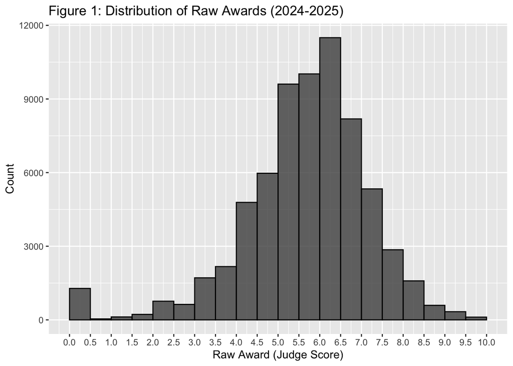

Figure 1 shows that scores are strongly concentrated between 5 and 7 points, indicating that most dives receive mid-range marks. Very low (0–2) and very high (9–10) scores are rare. Overall, judges tend to avoid the extreme ends of the scale and score most dives in a fairly central band.

#### 3.1.3.2 Raw score distribution by meet type

By plotting raw scores across meet types to see whether judging levels differ systematically between competition formats.

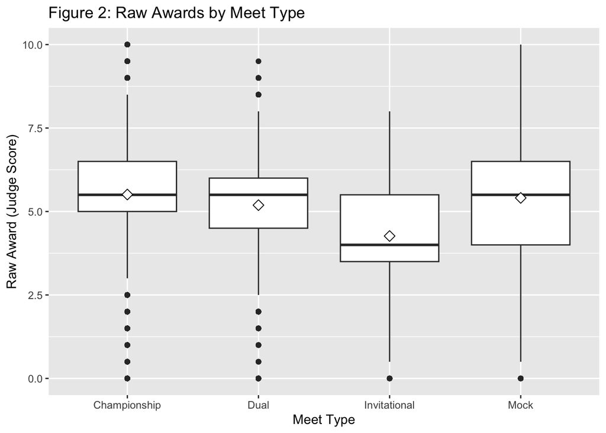

#### 3.1.3.3 Relationship between DD and raw award (scatter with smooth)

This plot examines how judge scores vary across different levels of dive difficulty, highlighting whether harder dives tend to receive higher or lower raw awards.

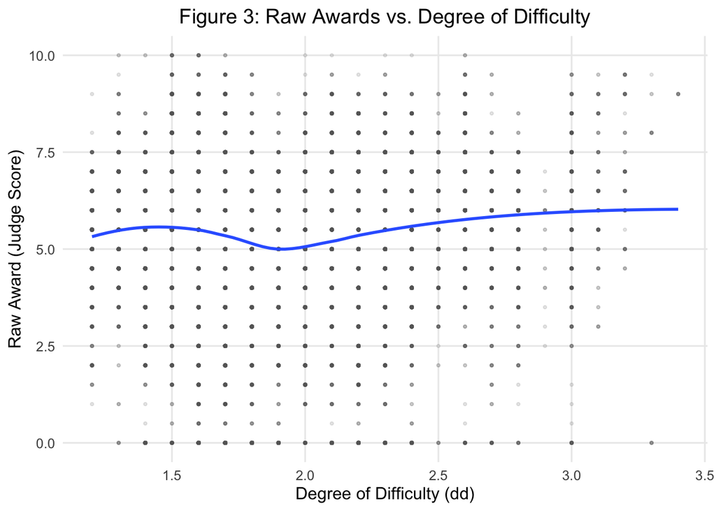

*Note: The degree of difficulty (DD) ranges from 1.2 to 3.4.*

Based on Figure 3, raw awards increase only slightly with higher degree of difficulty. The smooth trend is nearly flat with a mild upward slope at high DD values, suggesting judges generally score execution similarly across difficulty levels, with only modest reward for harder dives.

#### 3.1.3.4 Raw score distribution by diver gender

In this analysis, dives with missing or non-standard gender labels (“deleted” or “not specified”) are excluded from the dataset. This plot then compares raw scores between male and female divers to assess whether judges systematically score one group higher or lower.

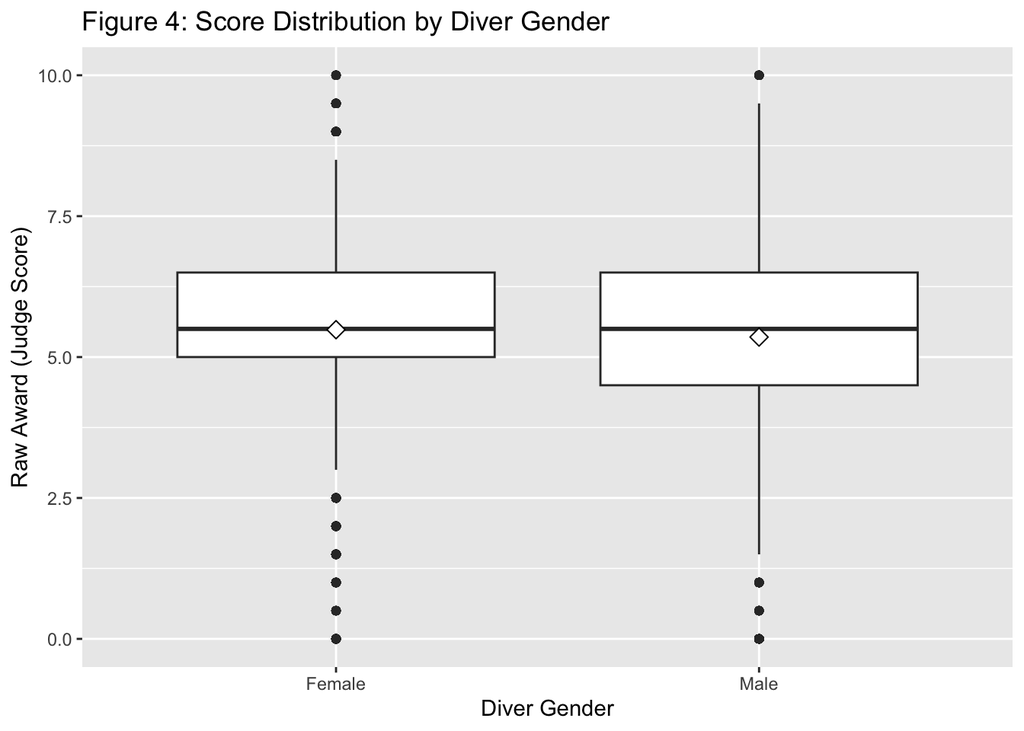

Figure 4 indicates that female and male divers receive very similar score distributions, with nearly identical medians and spreads; there is no strong evidence of systematic gender-based scoring differences in raw awards.

### 3.1.4 Judge-level stability and severity

This summary highlights how strict or lenient individual judges tend to be, and how stable their scoring patterns are relative to one another.

Table 3: Top 10 Judges by SD of Scores

| judge_id | judge_user_fullname | n_scores | mean_score | sd_score |
| --- | --- | --- | --- | --- |
| 8342 | Bobbie Ruasell | 409 | 4.57 | 2.47 |
| 1104 | Osvaldo Pito Alberty | 66 | 6.05 | 2.24 |
| 2875 | Janet Gabriel | 665 | 4.86 | 2.11 |
| 23558 | Victoria Moretti | 807 | 5.12 | 1.87 |
| 24926 | Addison Clark | 36 | 5.12 | 1.85 |
| 8994 | Karen Smalley | 132 | 4.71 | 1.79 |
| 9003 | Mike Wantuck | 108 | 5.38 | 1.75 |
| 27222 | Garrison Davis | 506 | 4.76 | 1.75 |
| 6105 | Kristin Fuhr | 1153 | 5.55 | 1.72 |
| 26253 | Angie Saunders | 176 | 4.29 | 1.69 |

Table 3 identifies the judges exhibiting the highest scoring variability as measured by the standard deviation of raw scores. The values range from 1.69 to 2.47, indicating that these officials utilize a significantly wider portion of the scoring scale. This high volatility is observed across varying sample sizes. Consequently, the analysis distinguishes between variation attributable to limited data and established scoring patterns within extensive records. Overall, this metric isolates specific judges who demonstrate greater fluctuation or a distinct interpretation of the scoring criteria compared to their peers.

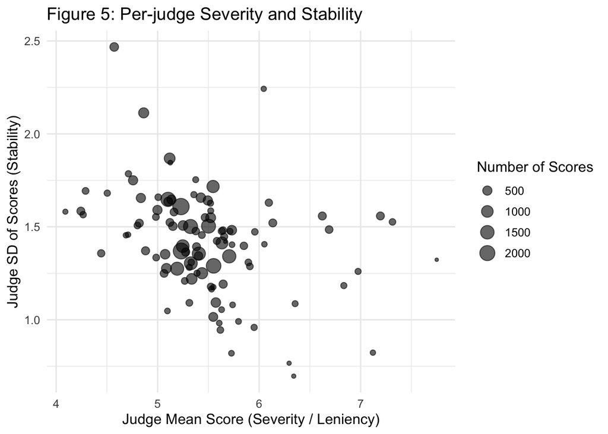

Based on Figure 5, among identified judges, average raw scores typically fall between about 4.3 and 5.6 points, with a few judges tending slightly higher. The top ten judges by score variability have standard deviations around 1.7–2.5 points, indicating fairly large spread in the awards they give. Some of these highly variable judges also handle a large number of dives (e.g., over 500–1,000 scores), so their instability reflects consistent practice rather than a few outliers. Overall, judges differ both in their typical severity/leniency and in how tightly they cluster their scores.

This plot shows each judge’s overall severity (mean score) and stability (standard deviation). Judges with low means tend to be stricter, while those with high means are more lenient. The standard deviation shows how consistent their scoring is. Most judges fall in a moderate range, but a few have unusually high variability, indicating inconsistent judging.

## 3.2 Judge-Level Scoring Framework and Performance Metrics

This section describes how the methodology is extended to the full historical dataset. Using the procedure described in Methods, judge-level severity, inconsistency, agreement, extremeness, and range-use scores were computed for 105 identified judges. The analysis starts from per-dive standardization within each panel and then aggregates these quantities to the judge level across meets. Finally, the judge-level metrics are converted into integrated performance scores and an overall rank for each judge. Because five judges appeared only in dives where the panel size was smaller than three and thus no valid residuals could be computed, they were excluded from the judge-level analysis, leaving 100 judges in the final ranking.

*Note: For ease of reading, the main text reports detailed results only for the 10 judges with the highest and 10 judges with the lowest composite ranks, with the full ranking table provided in Appendix B.*

Table 4: Top 10 Judges by Composite Performance Score

| Judge ID | Judge | Number of dives | Severity | Inconsistency | Agreement with panel | Extremeness | Range-use ratio | Overall rank |
| --- | --- | --- | --- | --- | --- | --- | --- | --- |
| 3155 | Brad Danker | 274 | 0.016 (12/100) | 0.463 (16/100) | 0.937 (8/100) | 0.531 (11/100) | 2.139 (6/100) | 1 |
| 1820 | Leah Hicks | 132 | 0.035 (25/100) | 0.423 (9/100) | 0.891 (58/100) | 0.500 (1/100) | 1.801 (2/100) | 2 |
| 2828 | Melisa Hyams | 221 | -0.049 (33/100) | 0.381 (3/100) | 0.945 (3/100) | 0.526 (9/100) | 3.179 (49/100) | 3 |
| 25266 | Sally Hansel | 209 | 0.017 (13/100) | 0.418 (8/100) | 0.941 (5/100) | 0.526 (9/100) | 3.501 (65/100) | 4 |
| 16984 | Daniela Bemme-Mora | 456 | 0.028 (18/100) | 0.424 (10/100) | 0.902 (47/100) | 0.548 (14/100) | 2.716 (21/100) | 5 |
| 1026 | Meredith Wagner | 154 | -0.164 (74/100) | 0.494 (28/100) | 0.934 (11/100) | 0.500 (1/100) | 1.937 (4/100) | 6 |
| 21496 | Kivanc Gur | 1257 | -0.004 (5/100) | 0.432 (11/100) | 0.929 (16/100) | 0.604 (46/100) | 3.205 (51/100) | 7 |
| 14731 | Brittany Campos | 55 | 0.050 (36/100) | 0.484 (22/100) | 0.935 (10/100) | 0.583 (30/100) | 3.025 (36/100) | 8 |
| 7394 | Fort Lauderdale High School COACH | 209 | -0.013 (11/100) | 0.487 (23/100) | 0.930 (15/100) | 0.523 (8/100) | 3.771 (79/100) | 9 |
| 27220 | Katie Monroe | 506 | -0.005 (6/100) | 0.572 (63/100) | 0.935 (9/100) | 0.560 (19/100) | 3.065 (41/100) | 10 |

Table 4 summarizes the judges who achieved the strongest performance across all five evaluation dimensions. The severity values are very close to zero and the inconsistency values are relatively small, which suggests these judges are neither systematically harsh nor lenient and are reasonably stable from dive to dive. Their agreement with the panel is high across the board, and the range-use ratios indicate that they make use of the scoring scale without being extreme outliers. Most of them have judged a substantial number of dives, so these patterns are based on a decent amount of information rather than just a few events.

Table 5: Bottom 10 Judges by Composite Performance Score

| Judge ID | Judge | Number of dives | Severity | Inconsistency | Agreement with panel | Extremeness | Range-use ratio | Overall rank |
| --- | --- | --- | --- | --- | --- | --- | --- | --- |
| 15478 | Juliana Bogaert | 176 | 0.670 (98/100) | 0.718 (94/100) | 0.862 (76/100) | 0.806 (97/100) | 2.212 (9/100) | 91 |
| 27222 | Garrison Davis | 506 | -0.101 (59/100) | 0.785 (96/100) | 0.877 (68/100) | 0.677 (85/100) | 3.709 (76/100) | 92 |
| 15937 | Jason Clark | 156 | 0.176 (75/100) | 1.013 (99/100) | 0.825 (89/100) | 0.863 (99/100) | 2.728 (23/100) | 93 |
| 16089 | Mike McGuire | 77 | 0.250 (89/100) | 0.661 (88/100) | 0.844 (84/100) | 0.767 (94/100) | 3.017 (34/100) | 94 |
| 3317 | Shelly Dresser | 66 | 0.405 (94/100) | 0.644 (83/100) | 0.613 (99/100) | 0.771 (95/100) | 2.725 (22/100) | 95 |
| 16034 | Donald Shroyer | 310 | 0.716 (99/100) | 0.851 (97/100) | 0.847 (82/100) | 0.822 (98/100) | 2.909 (30/100) | 96 |
| 8994 | Karen Smalley | 132 | 0.304 (92/100) | 0.669 (90/100) | 0.878 (67/100) | 0.663 (81/100) | 3.856 (83/100) | 97 |
| 24926 | Addison Clark | 36 | -0.118 (69/100) | 0.863 (98/100) | 0.780 (98/100) | 0.711 (89/100) | 3.509 (66/100) | 98 |
| 2902 | vernon feierstein | 88 | 0.307 (93/100) | 0.638 (82/100) | 0.852 (81/100) | 0.723 (92/100) | 3.666 (73/100) | 99 |
| 15481 | Jane Steele | 12 | 0.521 (96/100) | 1.404 (100/100) | 0.608 (100/100) | 1.222 (100/100) | 3.789 (80/100) | 100 |

Table 5 presents the judges with the lowest composite performance scores across five evaluation dimensions, displaying both metric values and relative ranks. This group generally exhibits elevated severity and high inconsistency, with rankings frequently clustering in the bottom percentile. Furthermore, agreement with the panel is notably weak, indicating a significant divergence from the collective scoring baseline. Since these patterns persist across substantial sample sizes, the observed deviations reflect systematic scoring behaviors rather than isolated irregularities. Consequently, these metrics highlight potential reliability concerns and identify specific candidates for targeted calibration or review.

## 3.3 Relationship between overall rank and judge-level metrics

After ranking judges by the composite performance score and listing the top and bottom panels in tables, it is helpful to see how each underlying metric changes across the full ranking. This plot treats overall rank as a continuum and shows how inconsistency, agreement, severity, range use, and extremeness evolve from the best to the worst judges.

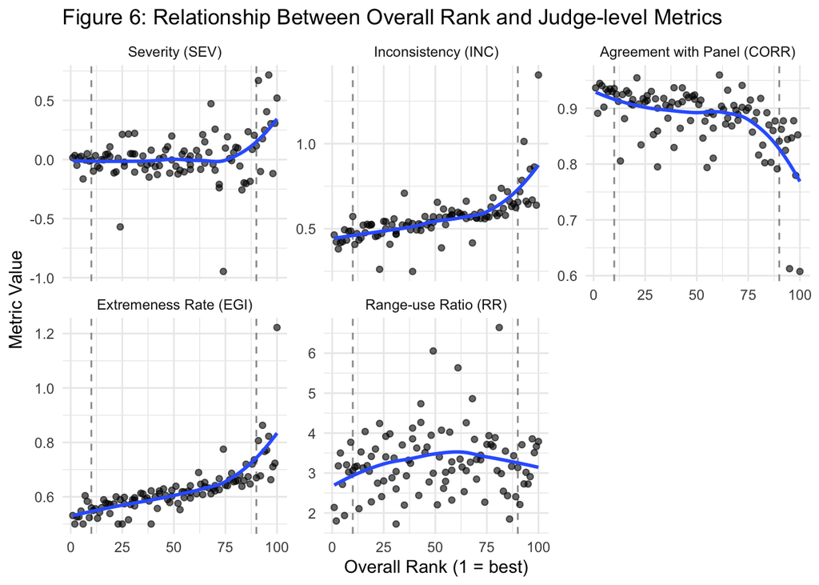

In Figure 6, the trend lines show a clear pattern: inconsistency (INC) rises steadily with worse rank and increases sharply among the bottom judges, while agreement with the panel (CORR) drifts downward and drops more sharply in the worst decile. Severity (SEV) stays close to zero for most judges and then becomes more positive for the lowest ranks, indicating a cluster of consistently high scorers. Range-use ratio (RR) is somewhat higher in the middle of the ranking but does not separate the extremes as strongly, whereas edge-importance (EGI) gradually increases and then spikes for the lowest-ranked judges, suggesting that their disagreements with the panel tend to occur on more consequential dives.

## 3.4 Comparison of key metrics for top vs bottom judges

Given the continuous patterns above, a direct side-by-side comparison of the best and worst judges helps quantify how far apart these groups really are. This figure focuses on the top 10 and bottom 10 judges and compares their distributions for the same set of metrics.

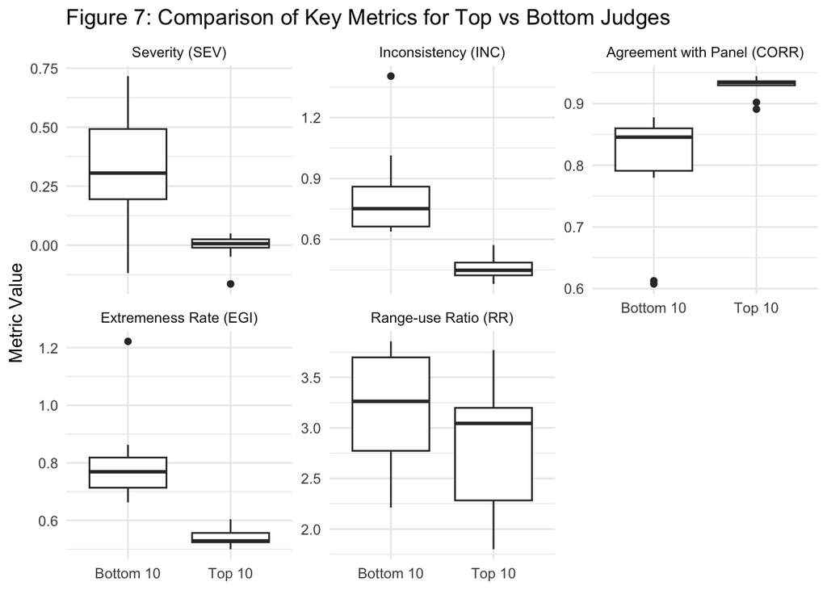

Based on Figure 7, the bottom 10 judges show noticeably higher inconsistency and more positive severity, while the top 10 cluster around lower INC values and SEV close to zero. Agreement with the panel is much stronger for the top group, with CORR tightly concentrated at high values, whereas the bottom group has both lower medians and more spread. The bottom judges also tend to have slightly larger range-use ratios, and their EGI values are clearly higher and more variable, suggesting that their disagreements with the panel occur more often on influential dives. Taken together, inconsistency, agreement, severity, and edge importance are the main features distinguishing the best and worst judges.

## 3.5 Correlation between overall rank and judge-level metrics

After visualizing patterns in the raw metrics, a compact summary of their association with the composite rank helps clarify which dimensions drive the ranking most strongly. The bar chart reports Spearman correlations between overall rank and each metric, treating higher ranks (larger numbers) as poorer performance.

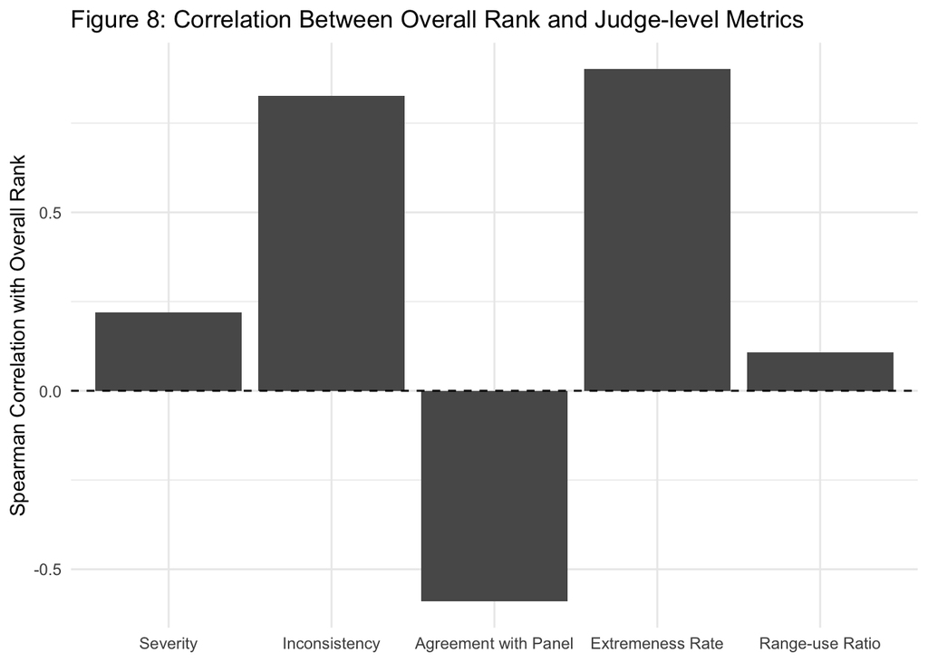

Figure 8 shows overall rank is most strongly and positively associated with edge importance (EGI), followed closely by inconsistency (INC), suggesting that judges who fall lower in the ranking tend both to disagree with their panels on more consequential dives and to be more variable overall. Agreement with the panel (CORR) shows a strong negative correlation, meaning lower-ranked judges deviate more from the consensus. Severity (SEV) has a modest positive correlation with rank, while range-use ratio (RR) is only weakly related, reinforcing that EGI, INC, and CORR are the primary drivers of the composite ordering.

## 3.6 Judge Inconsistency Summary Statistics

Table 6: Summary Statistics for Judge Inconsistency (INC)

| Min | Q1 | Median | Q3 | Max |
| --- | --- | --- | --- | --- |
| 0.249 | 0.492 | 0.559 | 0.599 | 1.404 |

Table 6 summarizes the distribution of judge inconsistency (INC), which ranges from approximately 0.249 to 1.404, with a first quartile of 0.492, a median of 0.559, and a third quartile of 0.599. These values establish benchmarks for interpreting individual judge performance, enabling comparisons against typical, lower-variability scoring behavior and identifying judges who fall well above or below expected inconsistency levels.

## 3.7 Judge-Level Bias Analyses

This section evaluates whether judges score certain groups of dives more favorably than others after controlling for panel baselines. Detailed judge lists can be provided in an appendix.

### 3.7.1 Gender-Based Scoring Differences

For each judge, the average residual on girls’ dives is compared with the average residual on boys’ dives. A positive difference indicates more generous scoring for girls; a negative difference indicates more generous scoring for boys.

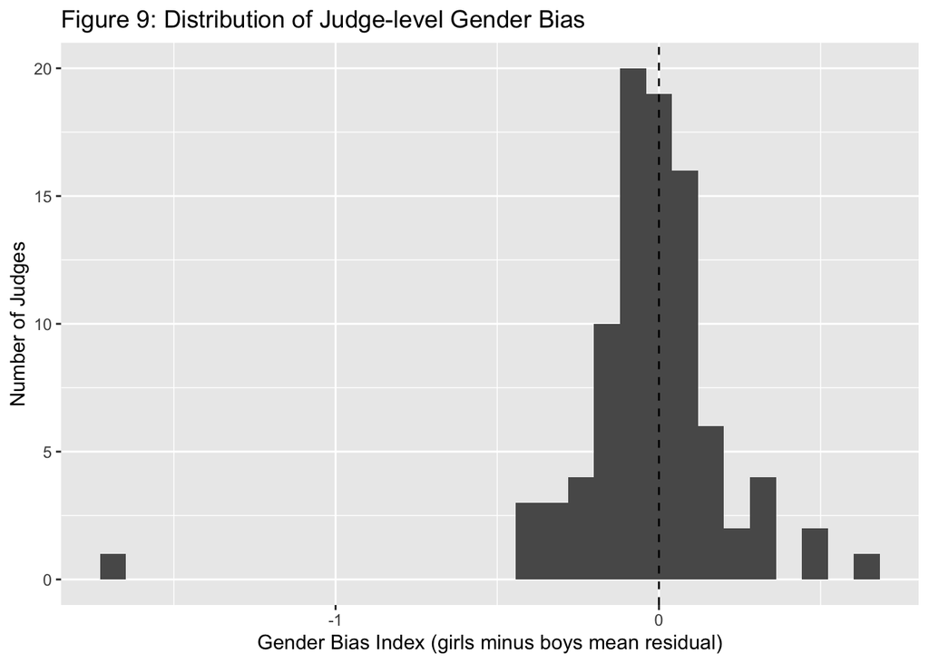

Figure 9 indicates that most judges sit very close to zero on this gender-bias index, so their average scores for girls and boys are almost the same. The bulk of the distribution is just slightly on the positive side, suggesting a small tendency to score girls a bit higher, and only a few judges show clearly stronger bias in either direction, including one clear negative outlier.

Table 7: Top 10 Judges Showing the Strongest Gender-related Scoring Bias

| judge_id | Judge | Girls dives | Boys dives | Bias (Girls - Boys) |
| --- | --- | --- | --- | --- |
| 15481 | Jane Steele | 6 | 6 | -1.708 |
| 16645 | Ben Mangini | 66 | 231 | 0.623 |
| 8944 | Tennille Haney | 55 | 33 | 0.505 |
| 3317 | Shelly Dresser | 55 | 11 | 0.486 |
| 8994 | Karen Smalley | 99 | 33 | -0.378 |
| 27220 | Katie Monroe | 410 | 96 | -0.374 |
| 8109 | Stephanie Reynolds | 99 | 66 | -0.371 |
| 2814 | William Walker | 66 | 496 | -0.360 |
| 27107 | Ernie Whalen | 99 | 66 | 0.355 |
| 15829 | Justin Luciano | 48 | 48 | -0.344 |

Table 7 shows the 10 judges with the largest gender-related differences in panel-adjusted scoring. Most judges in the dataset have gender-bias values close to zero, but this subset shows gaps ranging from roughly 0.34 to 1.71 points between girls’ and boys’ dives. Positive values (e.g Ben Mangini, Tennille Haney) correspond to judges who score girls more generously than boys, whereas negative values (e.g Jane Steele, Karen Smalley, Katie Monroe) indicate harsher scoring of girls or greater leniency toward boys. The most extreme case (Jane Steele) is based on only 6 dives per gender and should be interpreted cautiously, but taken together these patterns suggest a small number of judges may exhibit meaningful gender related differences in scoring that merit monitoring.

### 3.7.2 Difficulty-Related Bias

Difficulty-related bias compares, for each judge, mean residuals on low-degree-of-difficulty dives with those on high-degree-of-difficulty dives (split at the median difficulty).

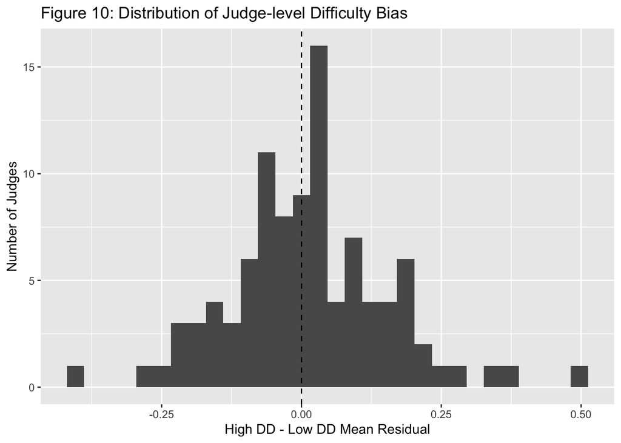

Table 8: Top 10 Judges Showing the Largest Difficulty-related Scoring Bias

| judge_id | Judge | Low DD dives | High DD dives | Bias (High - Low DD) |
| --- | --- | --- | --- | --- |
| 15829 | Justin Luciano | 28 | 68 | 0.513 |
| 8944 | Tennille Haney | 46 | 42 | -0.388 |
| 24926 | Addison Clark | 23 | 13 | 0.365 |
| 23558 | Victoria Moretti | 312 | 495 | 0.333 |
| 3418 | Michael Locke | 91 | 116 | 0.277 |
| 3434 | Nikki Hoagland | 224 | 241 | -0.274 |
| 3317 | Shelly Dresser | 32 | 34 | 0.256 |
| 27220 | Katie Monroe | 228 | 278 | -0.246 |
| 14697 | Hunter McCarter | 44 | 64 | -0.233 |
| 25504 | Yva Casanas | 33 | 55 | 0.224 |

Table 8 shows that only a small subset of judges display meaningful shifts in scoring severity based on dive difficulty. Although most judges maintain consistent scoring across the difficulty scale (as illustrated in the histogram), the top 10 outliers exhibit deviations of approximately 0.22 to 0.51 points between high-DD and low-DD dives after adjusting for panel baselines. Positive values (e.g Justin Luciano, Addison Clark) indicate a tendency to score harder dives more generously, whereas negative values (e.g Tennille Haney, Nikki Hoagland) indicate more generous scoring on easier dives. These discrepancies suggest that a few judges may unintentionally factor dive complexity into their execution scoring, which can introduce fairness concerns in events where athletes attempt more challenging routines.

### 3.7.3 Meet-Type Effects on Judge Scoring

To assess whether judges change severity across competition settings, a meet-type spread is computed for each judge as the difference between the highest and lowest mean residual across meet types (for example, dual meets, invitationals, championships).

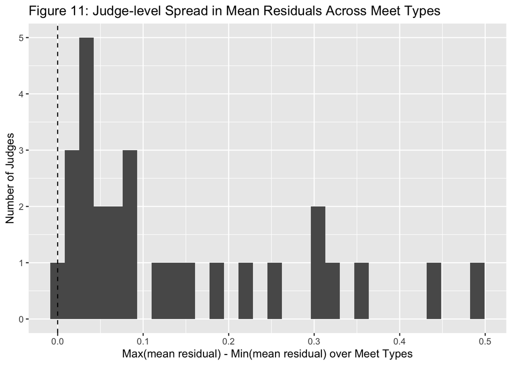

The histogram in Figure 11 shows the spread in mean residuals for all eligible judges. Most judges cluster near **0 to 0.10**, meaning they show only small shifts in severity between meet types. However, a noticeable tail extends beyond **0.30**, with a few judges changing their scoring behavior substantially depending on the setting.

Table 9: Top 10 Judges Showing the Largest Meet-type Scoring Shifts

| judge_id | Judge | Meet types used | Bias spread (max-min) |
| --- | --- | --- | --- |
| 15937 | Jason Clark | 2 | 0.491 |
| 14729 | Will Haney | 4 | 0.437 |
| 3325 | Stephanie Clark | 2 | 0.363 |
| 1142 | Ekaterina Odintsova | 2 | 0.321 |
| 14678 | Dana Bleich-Hagan | 2 | 0.304 |
| 857 | Derek Jones | 3 | 0.297 |
| 24847 | Sarah Guillot Register | 2 | 0.261 |
| 3345 | Kristy Nave | 2 | 0.224 |
| 1104 | Osvaldo Pito Alberty | 2 | 0.183 |
| 2728 | Taylor Malewicki | 2 | 0.158 |

Table 9 summarizes the judges who exhibit the largest scoring shifts across different meet types, after adjusting for panel baselines. While most judges in the dataset show only small differences in mean residuals between meet types (as seen in the histogram above), this group of outliers displays changes of approximately 0.16 - 0.49 points depending on the meet setting.

The Meet types used column reflects the number of competition categories (dual, championship, invitational) where the judge scored at least 5 dives, ensuring reliability of estimates by meet type. Because judges participate in different kinds of meets, this number varies across individuals, some only officiate dual meets and championships, while others also work invitationals or mock events.

Overall, these results indicate that environment dependent scoring behavior exists for a subset of judges. Judges with the largest spreads may be applying stricter standards in higher stakes or more competitive events, or becoming more lenient in familiar local formats. Targeted review and training for these individuals could improve consistency across meet contexts.

### 3.7.4 Team-Level Preferences in Scoring

Team-level bias is evaluated by comparing, for each judge, the mean residual for a specific team with the mean residual for all other teams combined, using only judge–team combinations with sufficient dives in both groups.

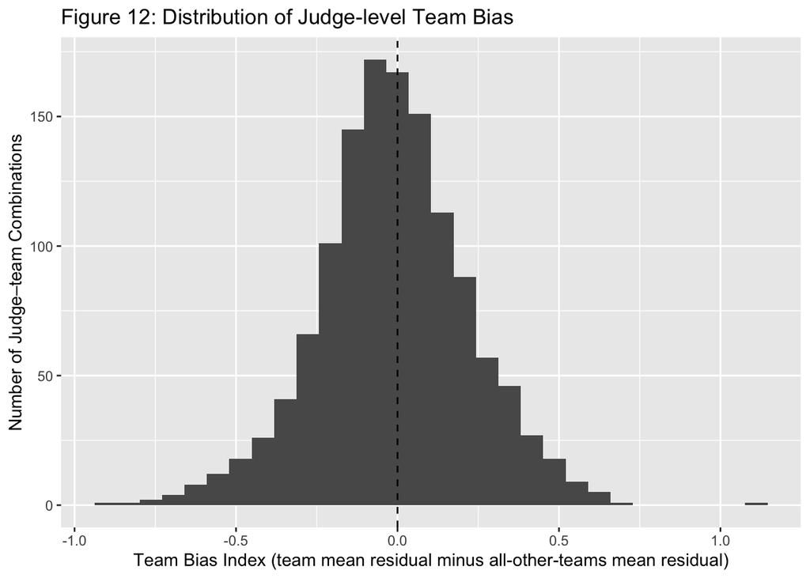

Table 10: Top 10 Judge–team Combinations Showing the Strongest Team-related Scoring Bias

| judge_id | Judge | Team | Team dives | Other dives | Bias (Team - Others) |
| --- | --- | --- | --- | --- | --- |
| 16645 | Ben Mangini | Titusville High School | 33 | 264 | 1.086 |
| 1015 | Anthony Perriello | Fort Lauderdale High School | 12 | 1650 | -0.928 |
| 9003 | Mike Wantuck | Lincoln High School | 6 | 102 | -0.837 |
| 9003 | Mike Wantuck | Lake Buena Vista High School | 6 | 102 | -0.793 |
| 1084 | Robert Sajdak | Boone High School | 6 | 1687 | -0.760 |
| 7386 | Astronaut High School COACH | Astronaut High School | 33 | 264 | 0.705 |
| 1015 | Anthony Perriello | Jensen Beach High School | 6 | 1656 | -0.695 |
| 2850 | Brian Payne | Winter Park High School | 11 | 572 | -0.686 |
| 8341 | Mike Taylor | Sunlake High School | 6 | 102 | -0.667 |
| 3154 | Brooke Powell | Lake Highland Prep School | 11 | 1370 | -0.664 |

Table 10 identifies the judge–team combinations with the largest deviations from panel-adjusted expectations. While team level effects across the full dataset are generally small, the outlier cases listed here exhibit shifts ranging from approximately 0.66 to 1.09 points, indicating either more favorable scoring (positive values) or stricter scoring (negative values) toward specific programs. These appear to be isolated judge specific patterns rather than systemic trends, however, the magnitude of the deviations suggests that targeted follow up or calibration may be warranted to ensure equitable evaluation across teams.

# 4 Conclusion

This report establishes a statistical framework designed to quantify and monitor the quality of diving judging. By analyzing over 44,000 scores from the 2024–2025 seasons, the study evaluates officials across five critical dimensions: severity, inconsistency, extremeness, agreement, and scoring range. Additionally, the analysis produces specific performance rankings for all identified judges. This framework serves as a scalable foundation for the Dive+ app ecosystem. It provides an effective mechanism to integrate advanced quality assurance features into the system and ensures a more robust, data-driven experience for the diving community.

# Reference

1. Maronna, R. A., Martin, R. D., & Yohai, V. J. (2019). Robust statistics: theory and methods (with R) (2nd ed.). Wiley. https://www.wiley.com/en-us/Robust+Statistics%3A+Theory+and+Methods+(with+R)%2C+2nd+Edition-p-9781119214687
2. Zitzewitz, E. (2006). Nationalism in Winter Sports Judging and Its Lessons for Organizational Decision Making. Journal of Economics & Management Strategy, 15(1), 67–99. https://onlinelibrary.wiley.com/doi/abs/10.1111/j.1530-9134.2006.00092.x
3. Emerson, J. W., Seltzer, M., & Lin, D. (2009). Assessing Judging Bias: An Example From the 2000 Olympic Games. The American Statistician, 63(2), 124–131. http://www.jstor.org/stable/25652240
4. Laird NM, Ware JH. Random-effects models for longitudinal data. Biometrics. 1982 Dec;38(4):963-74. PMID: 7168798.
5. Wickham, H., Hester, J., & Bryan, J. (2024). readr: Read Rectangular Text Data. R package version 2.1.5. https://CRAN.R-project.org/package=readr
6. Wickham, H., François, R., Henry, L., Müller, K., & Vaughan, D. (2023). dplyr: A Grammar of Data Manipulation. R package version 1.1.4. https://CRAN.R-project.org/package=dplyr
7. Wickham, H., Vaughan, D., & Girlich, M. (2024). tidyr: Tidy Messy Data. R package version 1.3.1. https://CRAN.R-project.org/package=tidyr
8. Wickham, H., & Henry, L. (2023). purrr: Functional Programming Tools. R package version 1.0.2. https://CRAN.R-project.org/package=purrr
9. Müller, K., & Wickham, H. (2023). tibble: Simple Data Frames. R package version 3.2.1. https://CRAN.R-project.org/package=tibble
10. Wickham, H. (2016). ggplot2: Elegant Graphics for Data Analysis. Springer-Verlag New York.
11. Nakazawa, M. (2024). fmsb: Functions for Medical Statistics Book with some Demographic Data. R package version 0.7.6. https://CRAN.R-project.org/package=fmsb
12. Xie, Y. (2023). knitr: A General-Purpose Package for Dynamic Report Generation in R. R package version 1.45.
13. Zhu, H. (2024). kableExtra: Construct Complex Table with ‘kable’ and Pipe Syntax. R package version 1.4.0. https://CRAN.R-project.org/package=kableExtra
14. Bates, D., Mächler, M., Bolker, B., & Walker, S. (2015). Fitting Linear Mixed-Effects Models Using lme4. Journal of Statistical Software, 67(1), 1–48. doi:10.18637/jss.v067.i01.
15. Chang, W., Cheng, J., Allaire, J. J., Sievert, C., Schloerke, B., Xie, Y., … & Borges, B. (2024). shiny: Web Application Framework for R. R package version 1.8.1. https://CRAN.R-project.org/package=shiny

# Appendix

## Appendix A

**Analytic Data Dictionary**

**Judge Identifiers**

`judge_id`: Unique user id for a judge, a null/blank value means the judge was anonymous

`judge_user_fullname`: Judge’s full name

`judge_number`: The chair in which the judge sat 1-7

**Meet & Event Identifiers**

`meet_id`: Unique identifier for the meet (competition).

`meet_name`: Official name of the meet.

`meet_type`: Category of the meet (dual, championship, invitational, mock).

`meet_date`: Last date of the meet.

`meet_location`: City, state of the meet

`event_id`: Unique identifier for the specific event (e.g., an ID for boys 1 meter).

`event_name`: Description of the event (e.g., Girl’s 1m high school).

**Diver & Team Identifiers**

`diver_id`: Unique identifier for the diver.

`diver_gender`: Gender of the diver (e.g., M, F).

`diver_team_id`: Unique identifier for the diver’s team.

`team_name`: Full name of the diver’s team

`team_abbreviation`: Abbreviated name of the diver’s team

`sheet_id`: Identifier for the original scoresheet, often unique to a diver in an event.

`dive_user_fullname`: Full name of the diver.

`coach_id`: Unique user id of the coach on the dive sheet.

`coach_fullname`: Full name of the coach on the dive sheet.

`submitted_dive_id`: Unique id of a dive competed in a meet.

`round_number`: Round number of the dive (1-11).

`dive_round_id`: Unique round id of a dive on a sheet.

`dive_code`: Dive number (e.g., 105, 201, 403).

`dive_position`: Positional letter of the dive code (e.g., A, B, C, D).

`Dive_height`: Height of the platform or board (e.g., 1M, 3M).

`dive_direction`: Directional group of the dive (e.g., forward, back, reverse, inward).

`dd`: The numeric Degree of Difficulty (DD) for the dive.

`dive_dd_id`: Unique id of a dive difficulty of the dive number, position, height, and governing body.

`Short_description`: Abbreviated text description of the dive.

`Description`: Full text description of the dive.

**Score Variable (Dependent Variable)**

`raw_award`: The individual score (0-10) given by the judge for the dive. This is the primary raw score before any calculations (e.g., dropping high/low scores or multiplying by DD).

**Judge Performance Metrics**

`Number of dives`: Total count of dives included in the analysis for which a leave-one-out panel baseline was computable.

`Severity`: The arithmetic mean of the residuals (defined as the judge’s score minus the leave-one-out panel baseline).

`Inconsistency`: The standard deviation of the judge’s residuals across all analyzed dives.

`Agreement with panel`: The Spearman rank correlation coefficient between the judge’s scores and the leave-one-out panel baselines.

`Extremeness rate`: The proportion of dives where the judge awarded the unique maximum or unique minimum score within the panel.

`Range-use ratio`: The ratio of the judge’s raw score standard deviation to the average within-panel standard deviation of the other judges.

## Appendix B

**All Judges: Performance Metrics and Composite Ranks**

| Judge ID | Judge | Number of dives | Severity | Inconsistency | Agreement with panel | Extremeness | Range-use ratio | Overall rank |
| --- | --- | --- | --- | --- | --- | --- | --- | --- |
| 3155 | Brad Danker | 274 | 0.016 (12/100) | 0.463 (16/100) | 0.937 (8/100) | 0.531 (11/100) | 2.139 (6/100) | 1 |
| 1820 | Leah Hicks | 132 | 0.035 (25/100) | 0.423 (9/100) | 0.891 (58/100) | 0.500 (1/100) | 1.801 (2/100) | 2 |
| 2828 | Melisa Hyams | 221 | -0.049 (33/100) | 0.381 (3/100) | 0.945 (3/100) | 0.526 (9/100) | 3.179 (49/100) | 3 |
| 25266 | Sally Hansel | 209 | 0.017 (13/100) | 0.418 (8/100) | 0.941 (5/100) | 0.526 (9/100) | 3.501 (65/100) | 4 |
| 16984 | Daniela Bemme-Mora | 456 | 0.028 (18/100) | 0.424 (10/100) | 0.902 (47/100) | 0.548 (14/100) | 2.716 (21/100) | 5 |
| 1026 | Meredith Wagner | 154 | -0.164 (74/100) | 0.494 (28/100) | 0.934 (11/100) | 0.500 (1/100) | 1.937 (4/100) | 6 |
| 21496 | Kivanc Gur | 1257 | -0.004 (5/100) | 0.432 (11/100) | 0.929 (16/100) | 0.604 (46/100) | 3.205 (51/100) | 7 |
| 14731 | Brittany Campos | 55 | 0.050 (36/100) | 0.484 (22/100) | 0.935 (10/100) | 0.583 (30/100) | 3.025 (36/100) | 8 |
| 7394 | Fort Lauderdale High School COACH | 209 | -0.013 (11/100) | 0.487 (23/100) | 0.930 (15/100) | 0.523 (8/100) | 3.771 (79/100) | 9 |
| 27220 | Katie Monroe | 506 | -0.005 (6/100) | 0.572 (63/100) | 0.935 (9/100) | 0.560 (19/100) | 3.065 (41/100) | 10 |
| 6457 | Elizabeth Perez | 968 | -0.098 (58/100) | 0.408 (5/100) | 0.925 (18/100) | 0.550 (15/100) | 3.150 (45/100) | 11 |
| 2795 | Sally Hansell | 897 | 0.034 (24/100) | 0.471 (19/100) | 0.912 (34/100) | 0.556 (17/100) | 3.172 (48/100) | 12 |
| 25504 | Yva Casanas | 88 | -0.057 (41/100) | 0.433 (12/100) | 0.806 (92/100) | 0.521 (7/100) | 2.108 (5/100) | 13 |
| 845 | Gregory Boardman | 209 | -0.072 (45/100) | 0.446 (13/100) | 0.925 (19/100) | 0.543 (13/100) | 3.528 (68/100) | 14 |
| 7533 | Pace High School COACH | 376 | 0.001 (1/100) | 0.521 (33/100) | 0.881 (63/100) | 0.560 (20/100) | 3.129 (43/100) | 15 |
| 3345 | Kristy Nave | 1690 | -0.003 (3/100) | 0.477 (21/100) | 0.931 (13/100) | 0.589 (34/100) | 4.038 (90/100) | 16 |
| 8858 | Stacy Thompson | 132 | 0.044 (27/100) | 0.526 (41/100) | 0.927 (17/100) | 0.577 (28/100) | 3.186 (50/100) | 17 |
| 724 | Jennifer Floyd | 568 | 0.048 (32/100) | 0.520 (32/100) | 0.908 (38/100) | 0.574 (26/100) | 3.046 (38/100) | 18 |
| 1015 | Anthony Perriello | 1662 | 0.026 (17/100) | 0.523 (37/100) | 0.916 (30/100) | 0.572 (23/100) | 3.415 (62/100) | 19 |
| 26880 | Jeff Gersonde | 176 | 0.108 (64/100) | 0.525 (40/100) | 0.906 (42/100) | 0.538 (12/100) | 2.279 (11/100) | 19 |
| 198 | Terry Horner | 235 | -0.113 (66/100) | 0.454 (14/100) | 0.955 (2/100) | 0.574 (24/100) | 3.602 (70/100) | 21 |
| 344 | Barb Parker | 176 | -0.104 (60/100) | 0.459 (15/100) | 0.908 (40/100) | 0.600 (43/100) | 2.747 (24/100) | 22 |
| 8596 | Kaitlin Peters | 22 | 0.011 (10/100) | 0.261 (2/100) | 0.834 (86/100) | 0.500 (1/100) | 4.241 (93/100) | 23 |
| 696 | Kimberly McCoy | 120 | -0.570 (97/100) | 0.472 (20/100) | 0.917 (27/100) | 0.590 (35/100) | 2.410 (14/100) | 24 |
| 8341 | Mike Taylor | 108 | 0.213 (84/100) | 0.543 (48/100) | 0.912 (36/100) | 0.500 (1/100) | 2.802 (27/100) | 25 |
| 8815 | Kathie McNeil | 275 | -0.055 (38/100) | 0.500 (29/100) | 0.923 (22/100) | 0.574 (24/100) | 3.918 (85/100) | 26 |
| 8098 | Ryan Just | 308 | -0.022 (15/100) | 0.542 (47/100) | 0.914 (33/100) | 0.598 (42/100) | 3.404 (61/100) | 26 |
| 15520 | Thomas Lugo | 187 | 0.217 (85/100) | 0.409 (6/100) | 0.930 (14/100) | 0.516 (6/100) | 3.981 (88/100) | 28 |
| 27107 | Ernie Whalen | 165 | 0.050 (35/100) | 0.523 (36/100) | 0.853 (80/100) | 0.571 (22/100) | 2.881 (29/100) | 29 |
| 1084 | Robert Sajdak | 1693 | 0.049 (34/100) | 0.558 (49/100) | 0.917 (28/100) | 0.589 (33/100) | 3.376 (59/100) | 30 |

[output cut: 70 more lines]